# Next Word Prediction - Exploratory Report

Najla AlAriefy

March 11, 2016

## Executive Summary

The data product that will be produced at the end of the project will be a text-prediction ShinyApp that will predict what the user would likely write next. This report will explore and summarize the data properties of the US blogs, twitter and news text datasets, before the building of the n-gram (n-grams are a series of associated tokens) model for predicting the next word based on the previous 1, 2, or 3 words.

## Preprocessing & Cleaning Decisions

It’s important to clean the data if we wanted the text prediction to return sound results. The following preprocessing decisions have been undergone, and there is room for suggestions:

- Merged words (Haven’t, Would’ve …etc) have been seperated to refine the results.
- Profane words have been removed using a dataset of 700 words.
- Punctuation marks and special symbols have been all removed. There is a plethora of smiley emoticons that have interferred between words.

## Data Summary and Profiling

It is important in text-prediction algorithms to confine the context. For instance, a person writing a business letter will use different words from a person who is tweeting or blogging. So for the perseverance of context, the prediction algorithms will run seperately on all three of the provided datasets.

[output not shown]

Most frequent first words for **twitter**:

```
## Most.Frequent.Words
##      I Thanks    You    The     RT     It     We   Just   What     My
##   2540    507    436    403    367    357    318    305    293    256
```

Most frequent first words for **blogs**:

```
## Most.Frequent.Words
##    I  The   It This   So  And   We   In    A   As
##  811  607  179  170  165  163  150  132  115  111
```

Most frequent first words for **news**:

```
## Most.Frequent.Words
##  The   In  But    A   It   He    I   As  And That
## 1183  252  210  168  127  121   92   86   80   77
```

## Sampling Decisions

Due to extremely restricted resources (4GB memory, low processor speed), it is deemed fit to sample a random 2% of each of the populations, with guaranteed reproducible results. Sample sizes (number of lines) are as follows:

| Context | Sample Size |
| --- | --- |
| Twitter | 47202 |
| Blogs | 17985 |
| News | 20204 |

Words occuring more than 1000 times in the **Twitter** sample (for computational restrictions, twitter only will be computed in this document):

[output not shown]

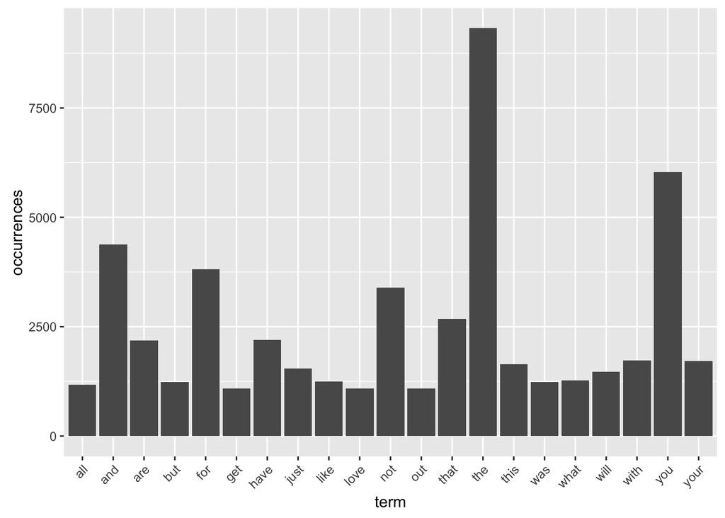